# Mesures pêches électriques

## 3.2 Lien entre variables qualitatives et quantitatives

**Cran de réglage du Héron**

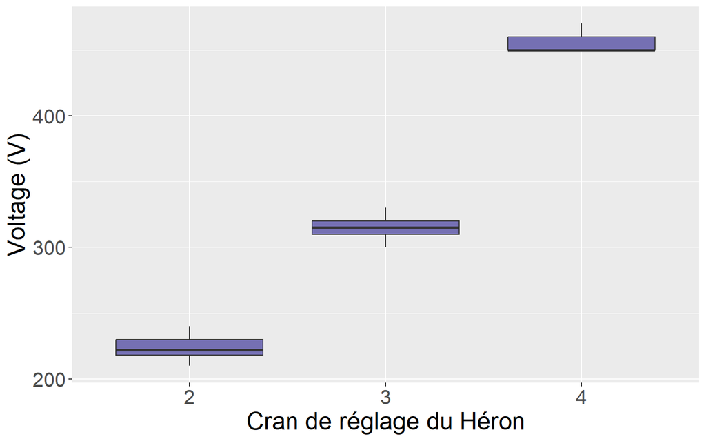

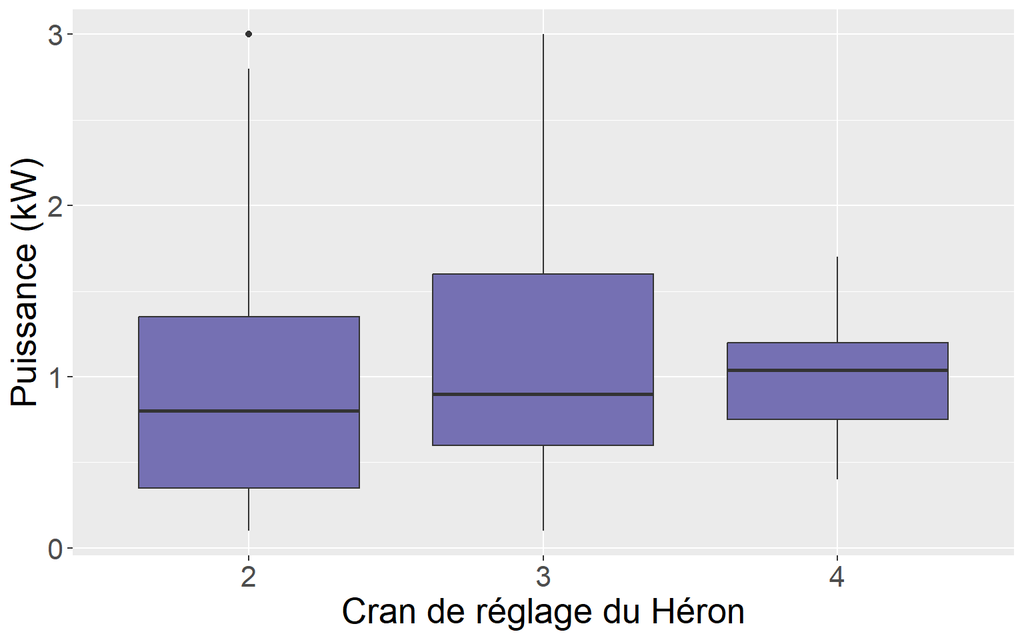

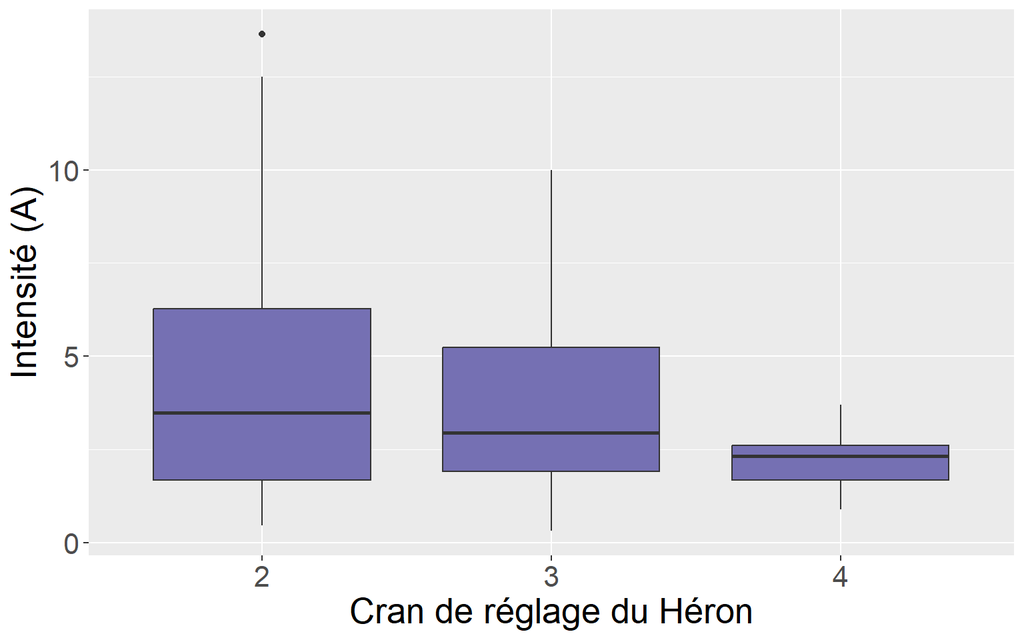

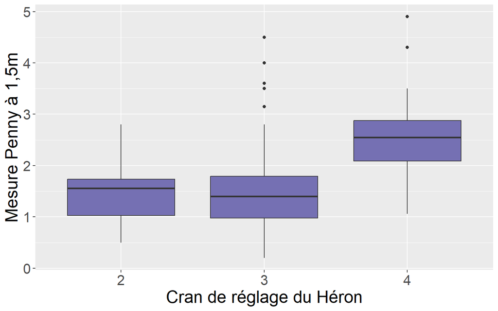

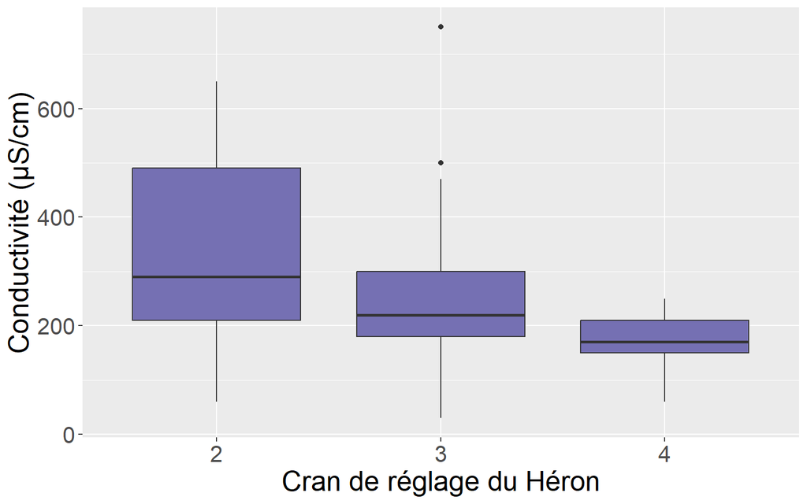

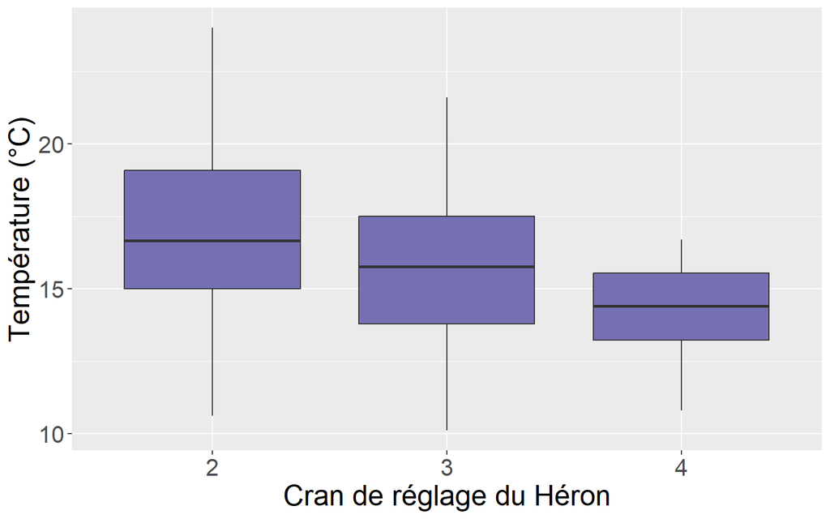

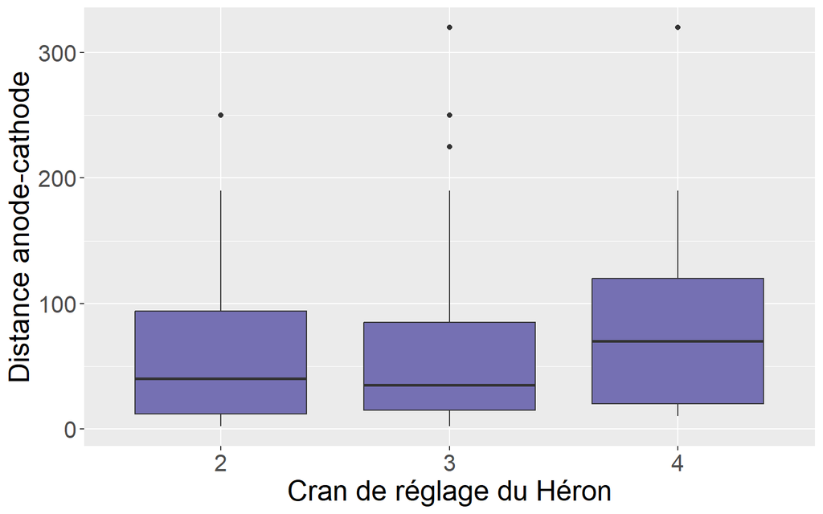

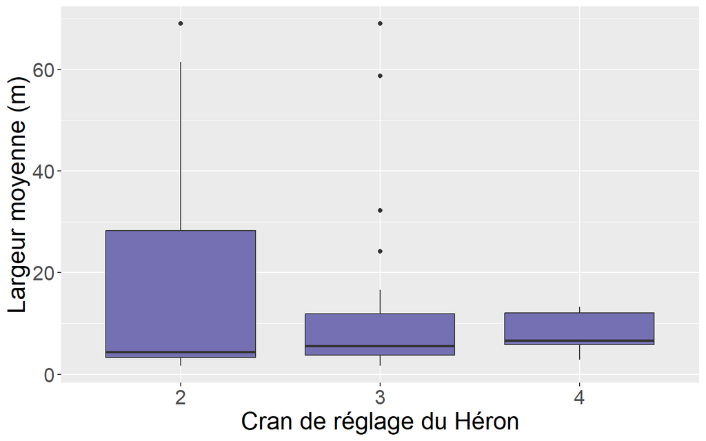

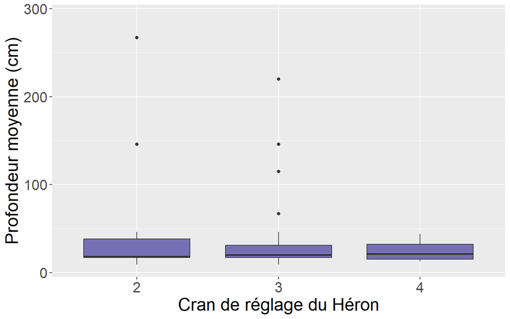

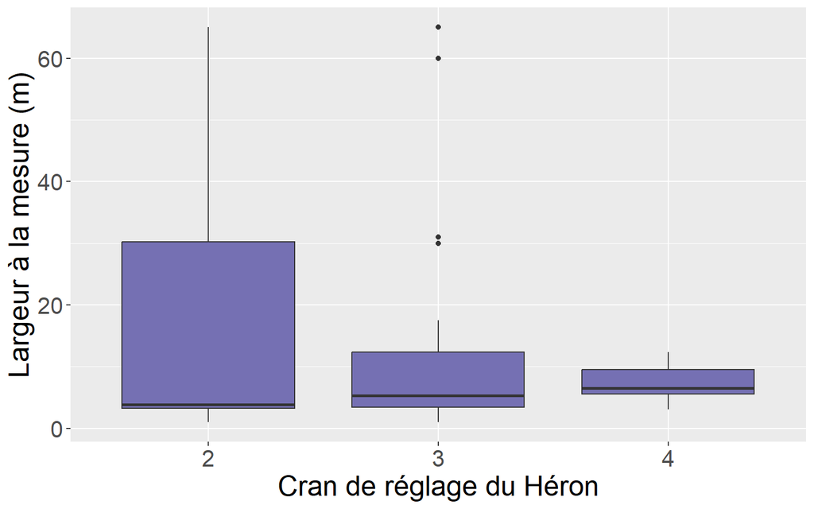

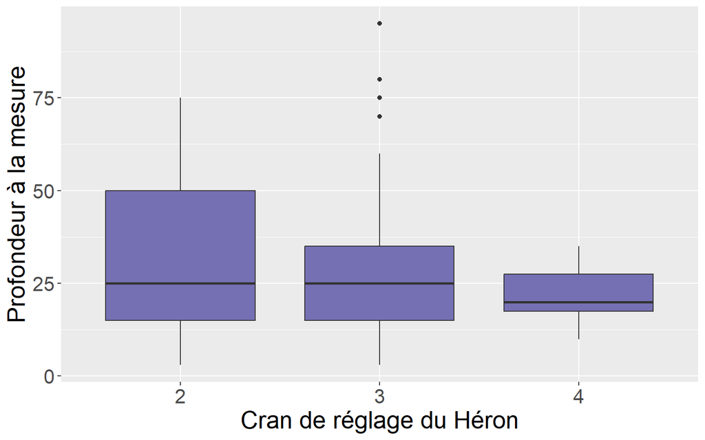

**Type de pêche**

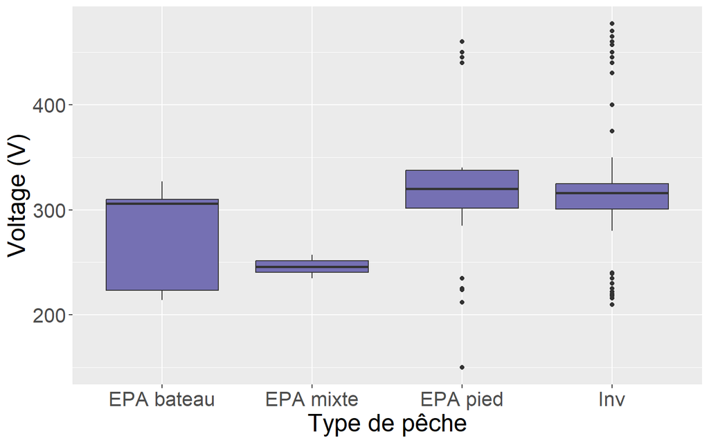

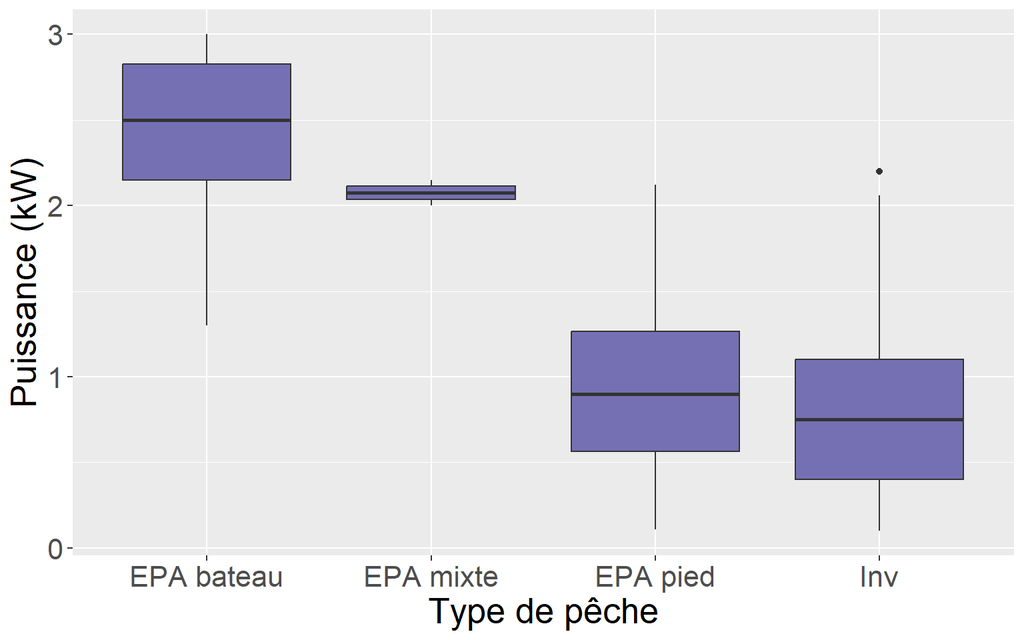

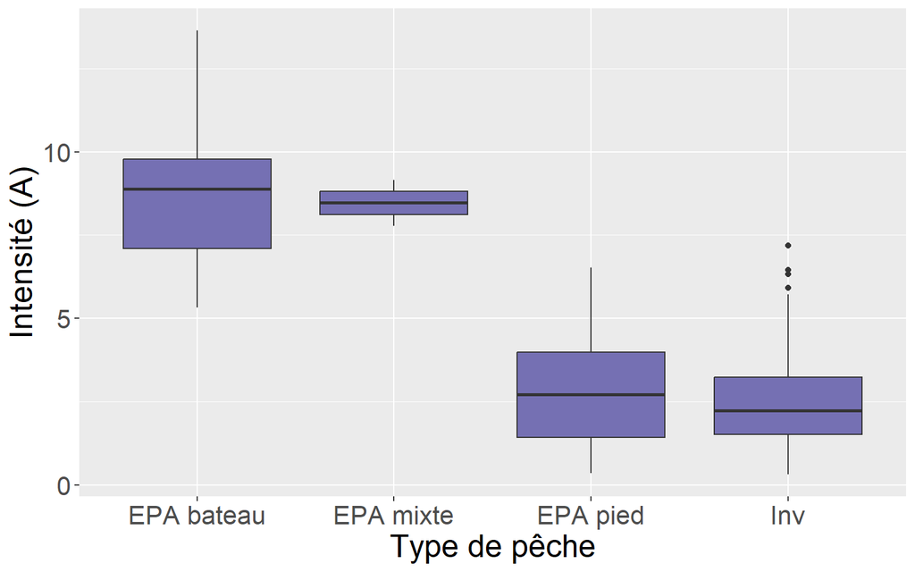

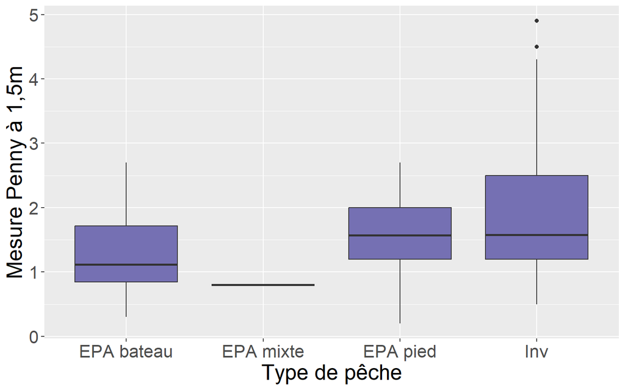

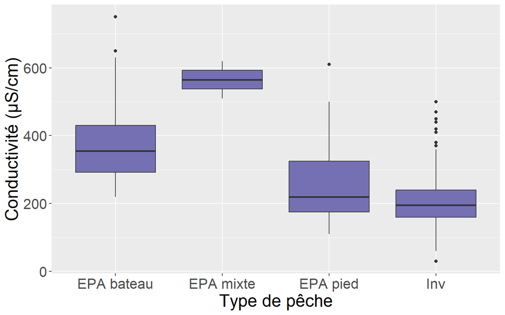

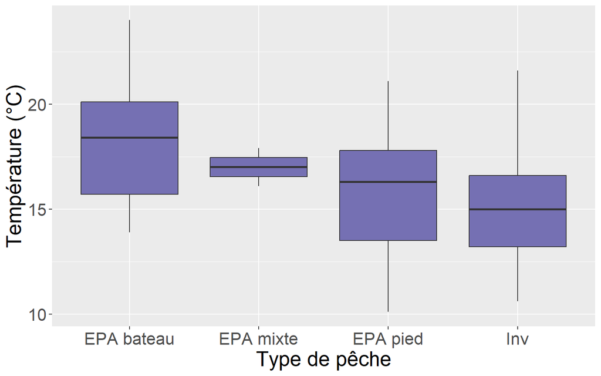

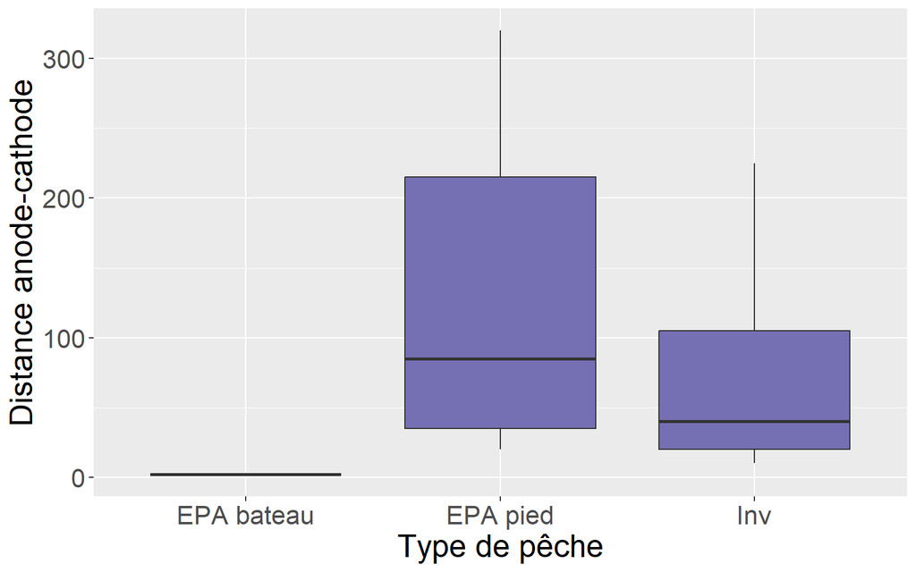

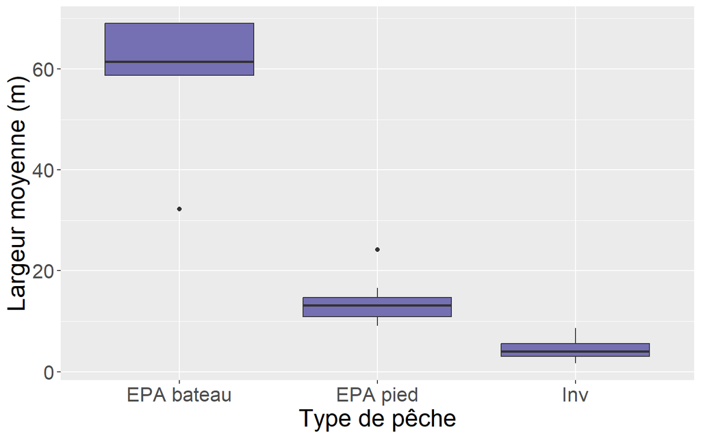

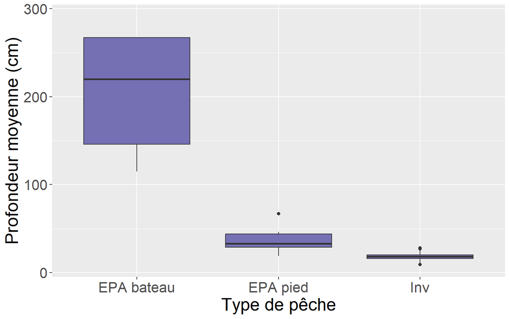

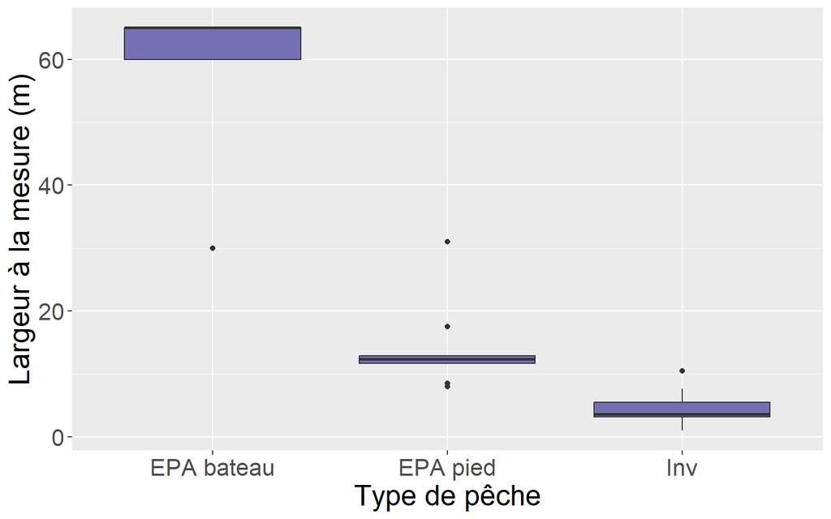

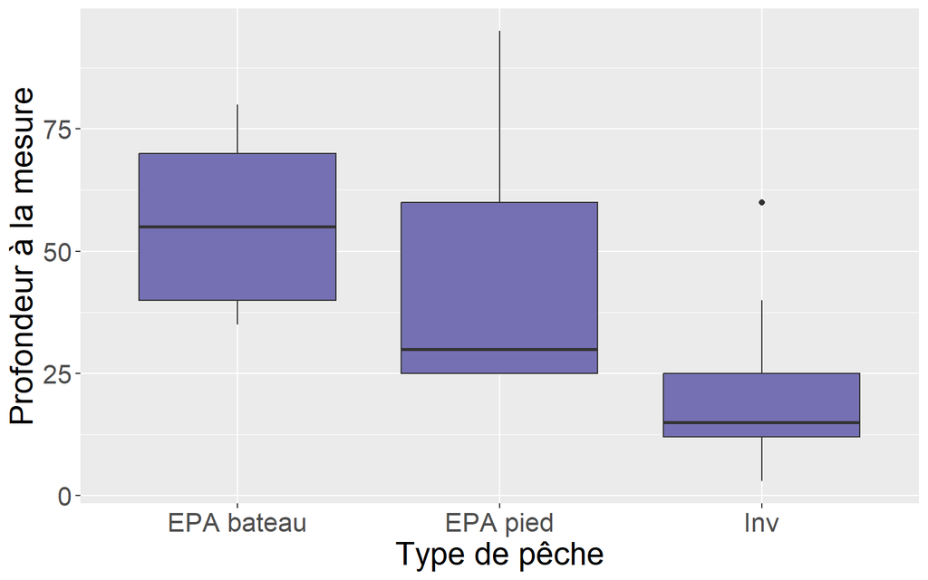

**Nombre d’anodes**

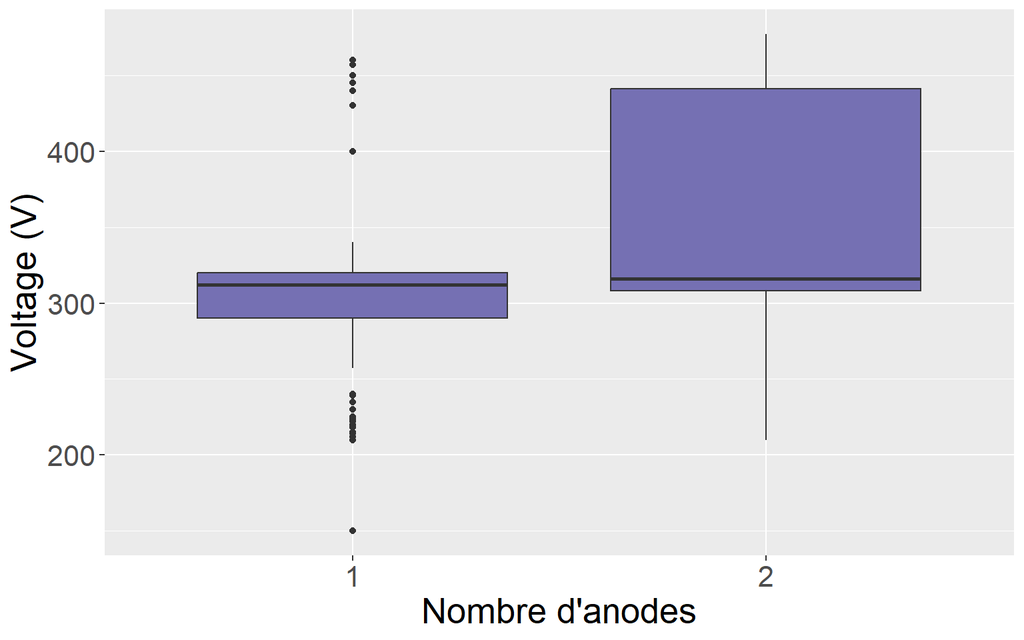

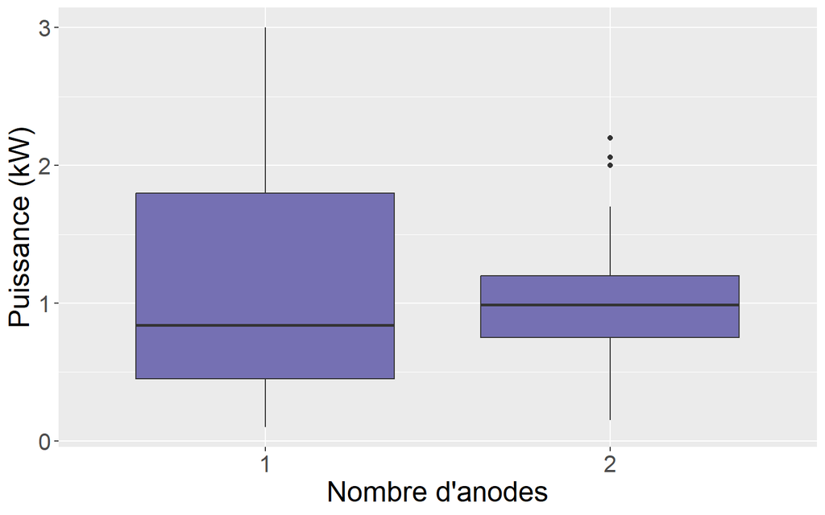

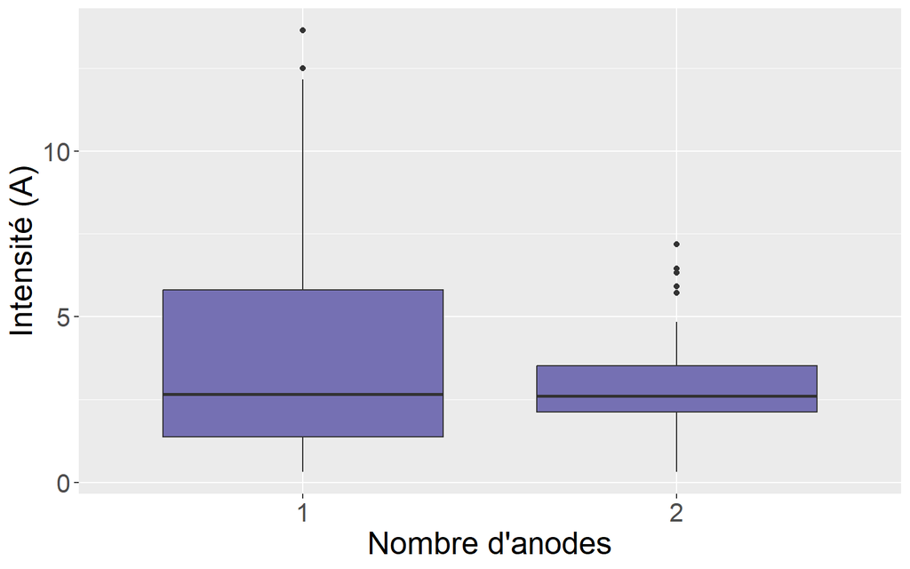

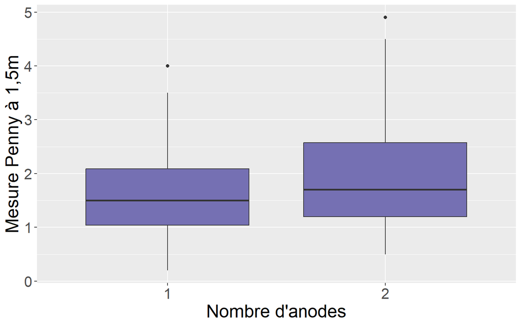

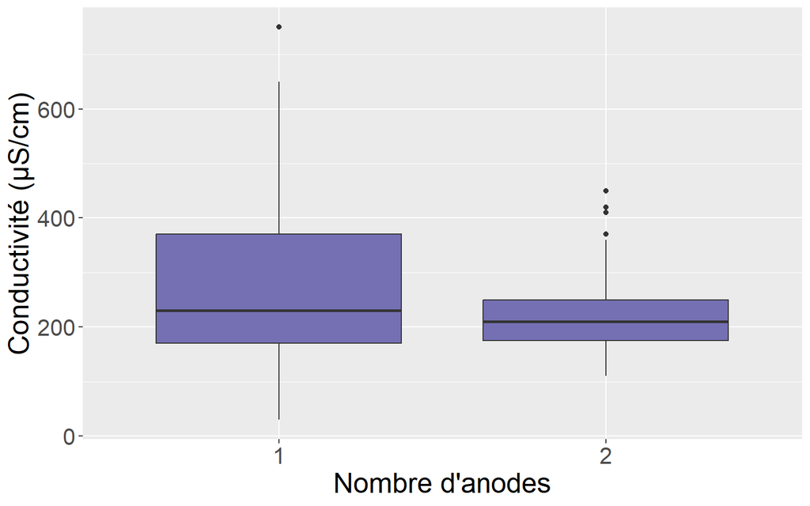

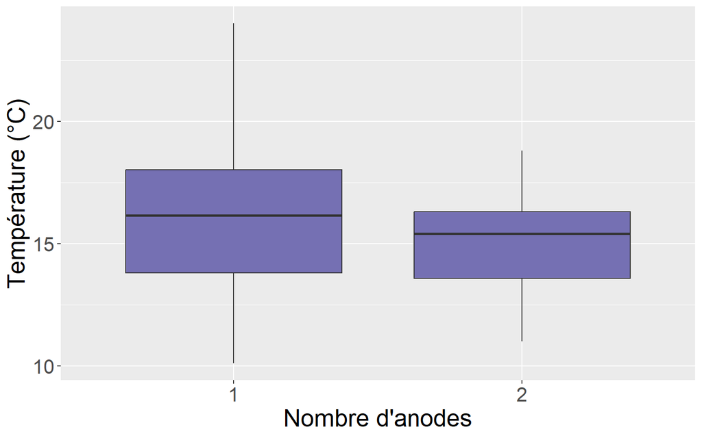

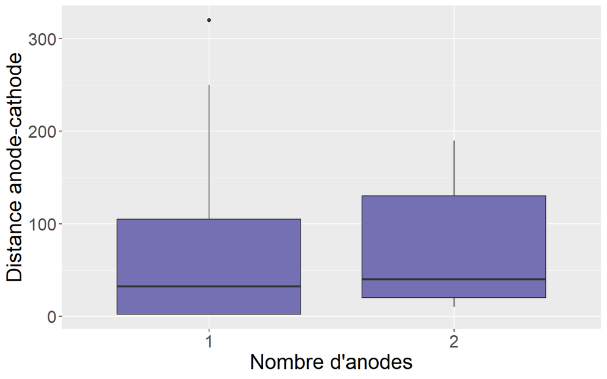

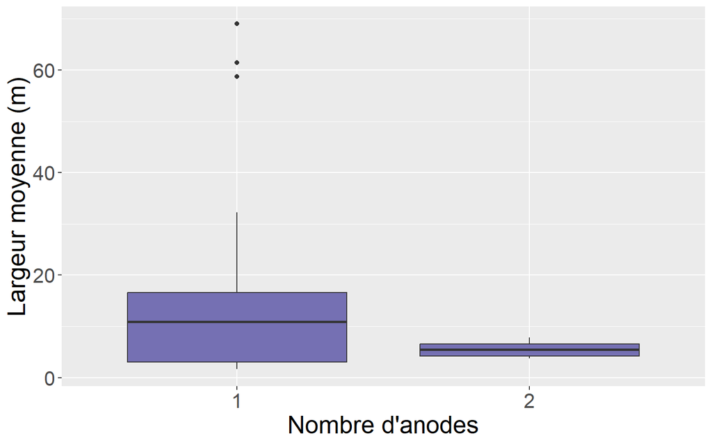

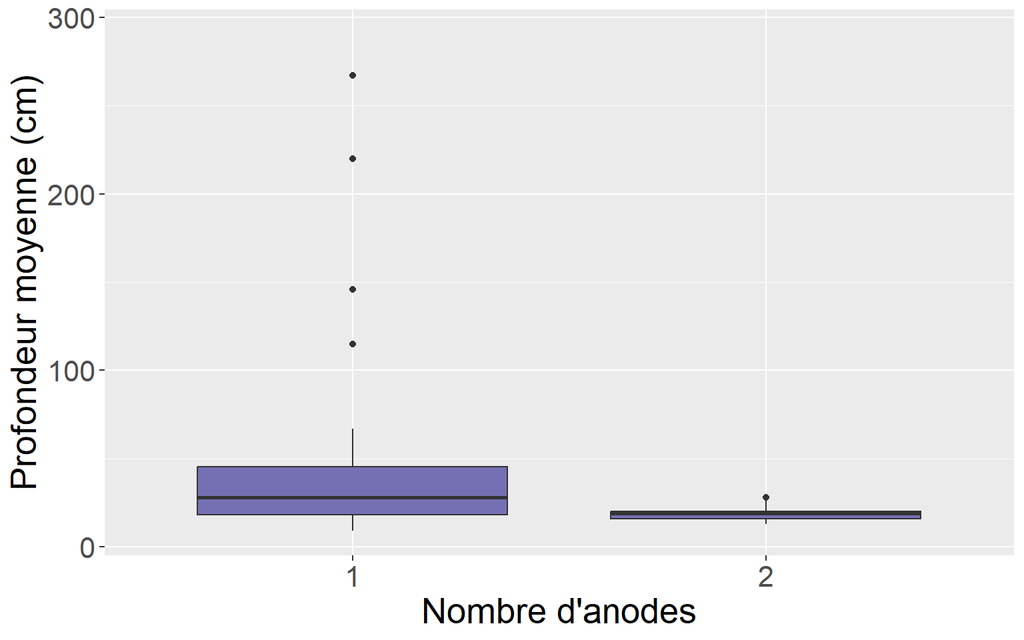

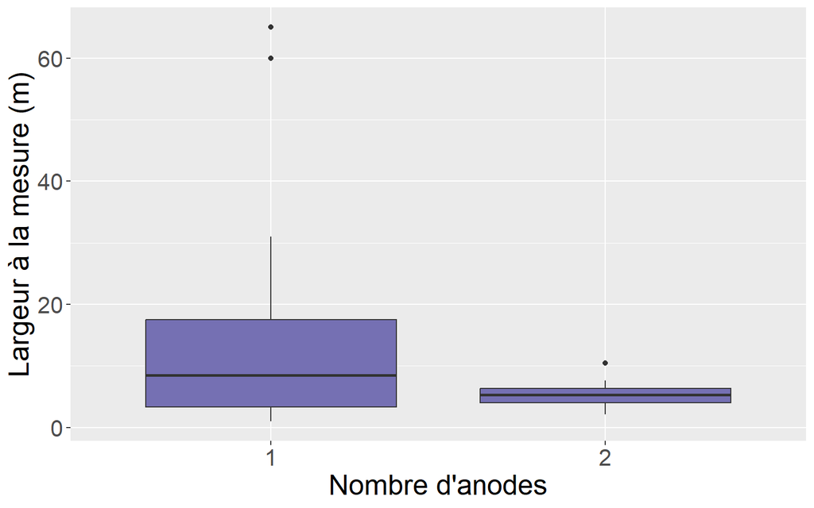

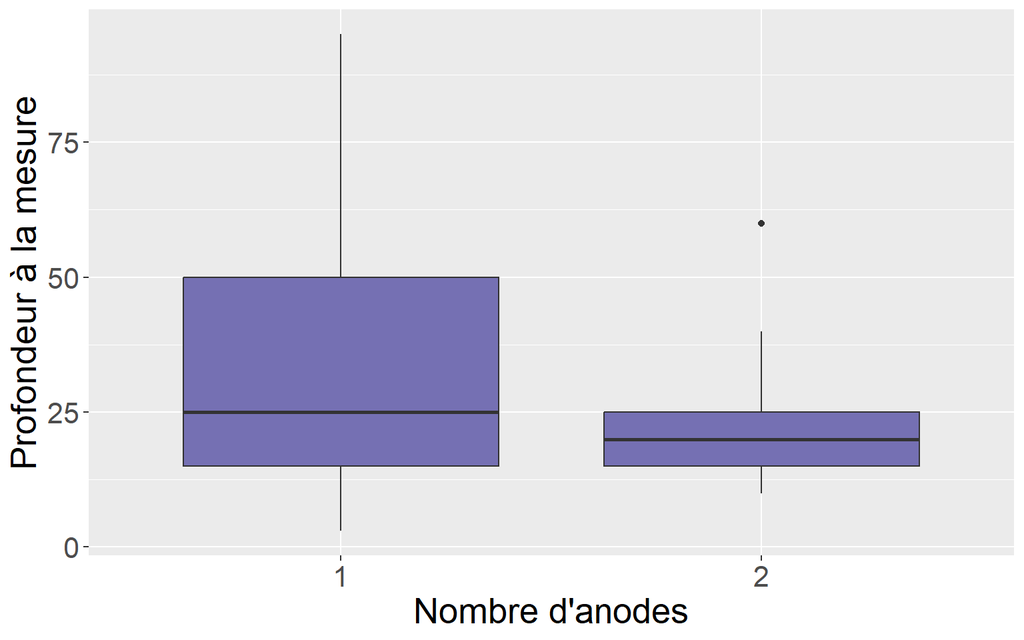

# 4 Analyse des mesures Penny

## 4.1 Relation entre mesure Penny et les autres variables

Pour estimer si la mesure Penny est liée à d’autres variables, il est possible de modéliser cette mesure en fonction d’autres variables quantitatives. Les matrices de corrélation on sait qu’en corrélation de Spearma, il existe un lien avec le voltage.

| Variable | Pente | Intercept | p-value | r² | Significativité |
| --- | --- | --- | --- | --- | --- |
| voltage | 0.006 | -0.059 | 3e-05 | 0.17 | *** |
| dc | 0.078 | 1.303 | 8e-05 | 0.16 | *** |
| conductivite | -0.002 | 2.328 | 0.00303 | 0.09 | ** |
| intensite | -0.093 | 2.087 | 0.0128 | 0.06 | * |
| larg_moy | -0.003 | 1.835 | 0.02945 | 0.05 | * |
| prof_moy | -0.004 | 1.898 | 0.04224 | 0.04 | * |
| puissance | -0.259 | 2.04 | 0.06256 | 0.04 | NS |
| larg_mes | -0.011 | 1.91 | 0.11709 | 0.03 | NS |
| prof_mes | -0.005 | 1.897 | 0.19139 | 0.02 | NS |
| dist_an_cat | -0.001 | 1.811 | 0.5737 | 0 | NS |

[output cut: 1 more lines]

On a donc la confirmation d’un lien statistique entre la mesure Penny et le voltage. La pente étant positive, la mesure Penny augmente quand le voltage augmente. Ce lien n’est toutefois pas très fort puisque le r² est de 17%, ce qui correspond à la part de la variabilité de la mesure Penny expliquée statistiquement par la variabilité du voltage.

On observe également des liens, mais moins forts, avec les variables dc, conductivite, intensite, larg_moy, prof_moy.

# 5 stabilité temporelle des valeurs ?

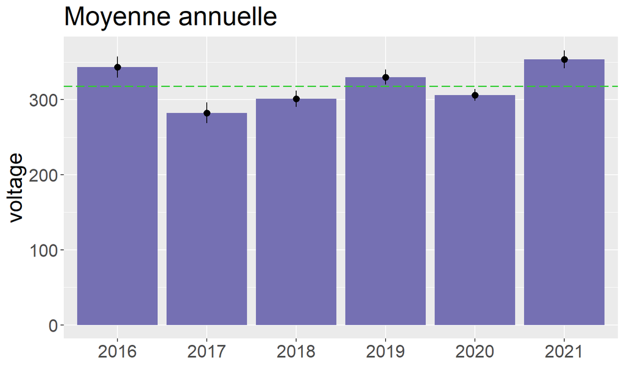

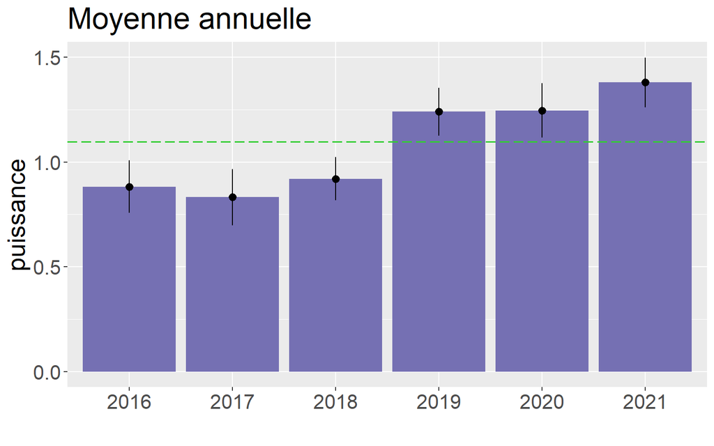

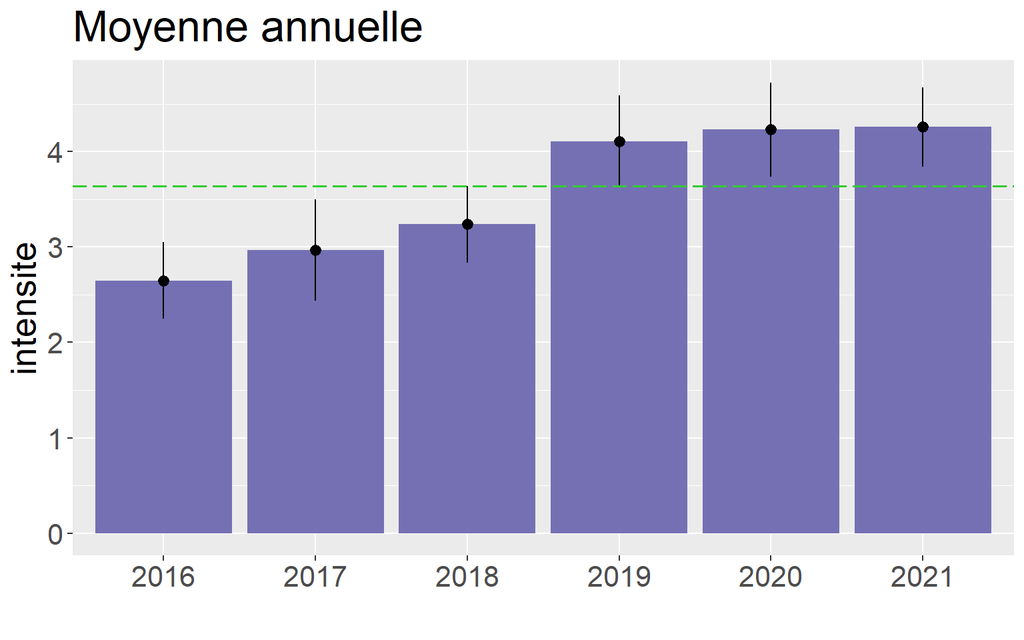

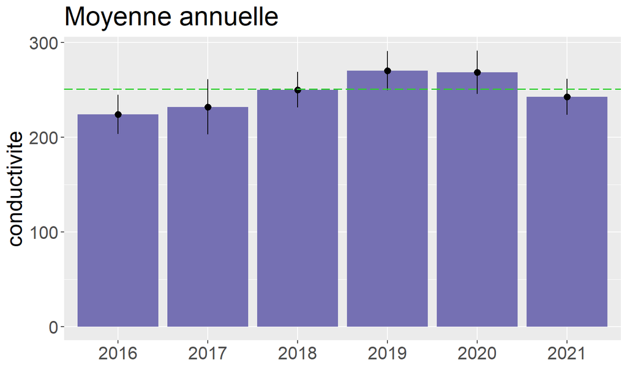

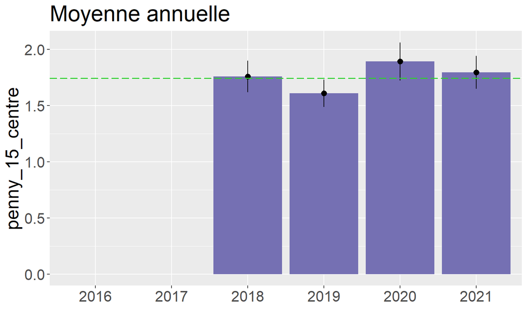

## 5.1 Cran de réglage

Sur le graphique ci-dessous les stations sont ordonnées selon leur conductivité moyenne.

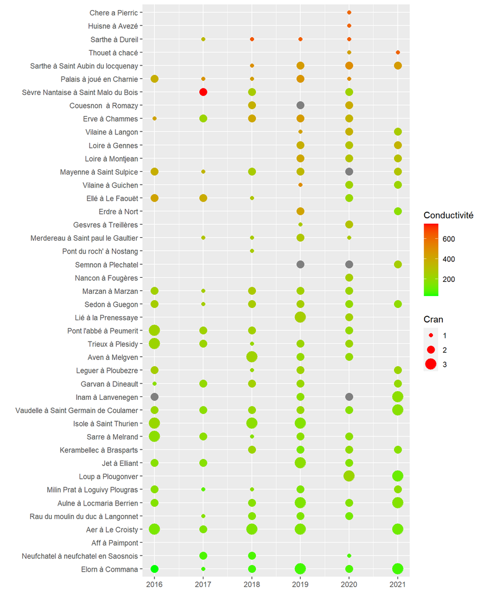

# 6 Le cran de réglage en fonction des autres variables

La question est de savoir s’il est possible de prédire le cran de réglage du Héron à partir des caractéristiques du site (les variables explicatives). On ne peut pas retenir comme variables explicatives celles qui sont elles-mêmes dépendantes du réglage du Héron (mesure Penny, intensité, etc.) sans quoi le raisonnement est circulaire. . Les variables explicatives “candidates” sont donc les caractéristiques générales du milieu (profondeur, largeur) et les mesures prises in situ en l’absence du courant électrique provoqué par l’appareil (conductivité, température).

## 6.1 Sélection des variables potentielles d’après les graphiques

Il est peu probable qu’une variable qui ne montre graphiquement aucun lien avec le cran de réglage ait un pouvoir explicatif. On commence donc par examiner les graphiques sur la colonne de gauche (cran) de la section 3.2.

On relève que trois des variables semblent avoir des distributions différentes selon le cran de réglage : la température, la profondeur moyenne de la rivière et la conductivité (on retient ici le paramètre conductivité à 25°C qui est celui mesuré sur le terrain).

Pour la modélisation, il faut que le tableau de données ne comporte pas de données manquantes.

```r
data_sel <-
  data %>% select(cran,
                  prof_moy,
                  conductivite,
                  temperature) %>%
  drop_na()
```

## 6.2 Colinéarite ?

```r
data_sel %>%
  mutate(cran = as.numeric(as.character(cran))) %>%
  round(2) %>%
  cor()
```

```
##                    cran   prof_moy conductivite temperature
## cran          1.0000000 -0.2149754   -0.4652662  -0.2571384
## prof_moy     -0.2149754  1.0000000    0.4513582   0.5158663
## conductivite -0.4652662  0.4513582    1.0000000   0.5570919
## temperature  -0.2571384  0.5158663    0.5570919   1.0000000
```

Ce n’est pas trop mal $\Rightarrow$ on peut passer à l’étape de modélisation

## 6.3 Modélisation

La variable que l’on cherche à prédire est le cran de réglage, qui peut prendre trois modalités (2, 3 ou 4) qui sont ordonnées. C’est une variable “ordinale”. On utilisera donc un modèle de type régression logistique ordonnée avec le package {MASS}.

La démarche comprend les étapes suivantes :

- Construction de modèles complets avec différents paramétrages
- Conservation du “meilleur”
- Essai de simplification en retirant des variables explicatives si ça ne détériore pas le modèle

La qualité du modèle final sera évaluée par le pourcentage de pêches où le cran prédit par le modèle est celui qui a été employé sur le terrain. En toute rigueur il aurait été souhaitable de construire le modèle sur une partie des données et de le tester sur une autre partie, mais le nombre des observations étant limité, il aurait été dommage d’en écarter certaines pour élaborer le modèle.

La qualité des modèles intermédiaires sera évaluée sur le [critère d’Akaike (AIC)](https://fr.wikipedia.org/wiki/Crit%C3%A8re_d%27information_d%27Akaike). Plus sa valeur est faible, meilleur est l’ajustement.

### 6.3.1 Tests du modèle complet

On commence par construire le modèle complet (avec les 3 variables explicatives) en essayant plusieurs paramétrages (logistique, probit …).

D’après l’AIC on a de meilleurs résultats avec le modèle “cloglog”.

Un autre critère de la qualité du modèle est le pourcentage des “crans” qui sont bien prédits.

Pour ce modèle il est de 73%.

### 6.3.2 Possibilité de le simplifier ?

On procède par étape au moyen de la fonction `stepAIC` du package `MASS`.

Celle-ci nous indique (non montré ici) que si l’on veut retirer une variable c’est la profondeur moyenne.

On construit donc le modèle : *cran ~ conductivite + temperature*

Taux de bien classés : 73%.

$\Rightarrow$ ce modèle est aussi bon que le précédent en prédiction, mais plus simple (seulement deux variables explicatives). On le retirnt donc.

Des essais ont montré que si l’on simplifie encore le modèle (pour ne conserver que la variable explicative `conductivite`), le modèle perd en capacité prédictive.

La matrice de confusion du modèle retenu est la suivante :

| Cran observé | Cran prédit par modèle 2 | Cran prédit par modèle 3 | Cran prédit par modèle 4 |
| --- | --- | --- | --- |
| 2 | 6 | 10 | 1 |
| 3 | 1 | 62 | 2 |
| 4 | 0 | 12 | 2 |